# Project: Hospital No Show Appointments Data Analysis

- Introduction
- Data Wrangling
- Exploratory Data Analysis
- Conclusions

## Introduction

> In this project, we will be taking a look at a dataset provided by Brazilian hospitals. The dataset contains information of more than a hundred thousand patients and their respective pre-existing conditions, whether they are part of the scholarship, received a text reminder and if they showed up to their appointment or not. The purpose of this project is to see if there are any relationships or insights as to why people may or may not show up to their doctor's apppointment. Specifically, we will be asking the following questions:

> 1) Does receiving a text reminder help with appointment turn out?

> 2) Can scholarship status help provide hints as to whether a patient shows up or not.

> 3) Are older people more likely to show up to an apppointment?

> We want to have a clearer understanding in order to see if Brazil can minimize no shows, so we will be diving deeping into these questions by analyzing the data.

# Import Packages

```python
import pandas as pd
import numpy as np
import matplotlib.pyplot as plt
import seaborn as sns
```

## Data Wrangling

### General Properties

> I will be saving the csv file as 'df' and investigate the dataset and look for any irregularities or other things of interest. The next step will be to inspect the csv file to see how many rows, columns, null values (if any).

```python
df = pd.read_csv('project2.csv')
df.head()
```

|  | PatientId | AppointmentID | Gender | ScheduledDay | AppointmentDay | Age | Neighbourhood | Scholarship | Hipertension | Diabetes | Alcoholism | Handcap | SMS_received | No-show |
| --- | --- | --- | --- | --- | --- | --- | --- | --- | --- | --- | --- | --- | --- | --- |
| 0 | 2.987250e+13 | 5642903 | F | 2016-04-29T18:38:08Z | 2016-04-29T00:00:00Z | 62 | JARDIM DA PENHA | 0 | 1 | 0 | 0 | 0 | 0 | No |
| 1 | 5.589978e+14 | 5642503 | M | 2016-04-29T16:08:27Z | 2016-04-29T00:00:00Z | 56 | JARDIM DA PENHA | 0 | 0 | 0 | 0 | 0 | 0 | No |
| 2 | 4.262962e+12 | 5642549 | F | 2016-04-29T16:19:04Z | 2016-04-29T00:00:00Z | 62 | MATA DA PRAIA | 0 | 0 | 0 | 0 | 0 | 0 | No |
| 3 | 8.679512e+11 | 5642828 | F | 2016-04-29T17:29:31Z | 2016-04-29T00:00:00Z | 8 | PONTAL DE CAMBURI | 0 | 0 | 0 | 0 | 0 | 0 | No |
| 4 | 8.841186e+12 | 5642494 | F | 2016-04-29T16:07:23Z | 2016-04-29T00:00:00Z | 56 | JARDIM DA PENHA | 0 | 1 | 1 | 0 | 0 | 0 | No |

```python
df.shape
```

```
(110527, 14)
```

```python
df.info()
```

```
<class 'pandas.core.frame.DataFrame'>
RangeIndex: 110527 entries, 0 to 110526
Data columns (total 14 columns):
 #   Column          Non-Null Count   Dtype
---  ------          --------------   -----
 0   PatientId       110527 non-null  float64
 1   AppointmentID   110527 non-null  int64
 2   Gender          110527 non-null  object
 3   ScheduledDay    110527 non-null  object
 4   AppointmentDay  110527 non-null  object
 5   Age             110527 non-null  int64
 6   Neighbourhood   110527 non-null  object
 7   Scholarship     110527 non-null  int64
 8   Hipertension    110527 non-null  int64
 9   Diabetes        110527 non-null  int64
 10  Alcoholism      110527 non-null  int64
 11  Handcap         110527 non-null  int64
 12  SMS_received    110527 non-null  int64
 13  No-show         110527 non-null  object
dtypes: float64(1), int64(8), object(5)
memory usage: 11.8+ MB
```

> As I glance over the dataset, I can spot some columns that I probably won't be needing for my analysis. 'PatientId', for example, will be one I will be deleting to make it cleaner to the eye.

```python
df.describe()
```

|  | PatientId | AppointmentID | Age | Scholarship | Hipertension | Diabetes | Alcoholism | Handcap | SMS_received |
| --- | --- | --- | --- | --- | --- | --- | --- | --- | --- |
| count | 1.105270e+05 | 1.105270e+05 | 110527.000000 | 110527.000000 | 110527.000000 | 110527.000000 | 110527.000000 | 110527.000000 | 110527.000000 |
| mean | 1.474963e+14 | 5.675305e+06 | 37.088874 | 0.098266 | 0.197246 | 0.071865 | 0.030400 | 0.022248 | 0.321026 |
| std | 2.560949e+14 | 7.129575e+04 | 23.110205 | 0.297675 | 0.397921 | 0.258265 | 0.171686 | 0.161543 | 0.466873 |
| min | 3.921784e+04 | 5.030230e+06 | -1.000000 | 0.000000 | 0.000000 | 0.000000 | 0.000000 | 0.000000 | 0.000000 |
| 25% | 4.172614e+12 | 5.640286e+06 | 18.000000 | 0.000000 | 0.000000 | 0.000000 | 0.000000 | 0.000000 | 0.000000 |
| 50% | 3.173184e+13 | 5.680573e+06 | 37.000000 | 0.000000 | 0.000000 | 0.000000 | 0.000000 | 0.000000 | 0.000000 |
| 75% | 9.439172e+13 | 5.725524e+06 | 55.000000 | 0.000000 | 0.000000 | 0.000000 | 0.000000 | 0.000000 | 1.000000 |
| max | 9.999816e+14 | 5.790484e+06 | 115.000000 | 1.000000 | 1.000000 | 1.000000 | 1.000000 | 4.000000 | 1.000000 |

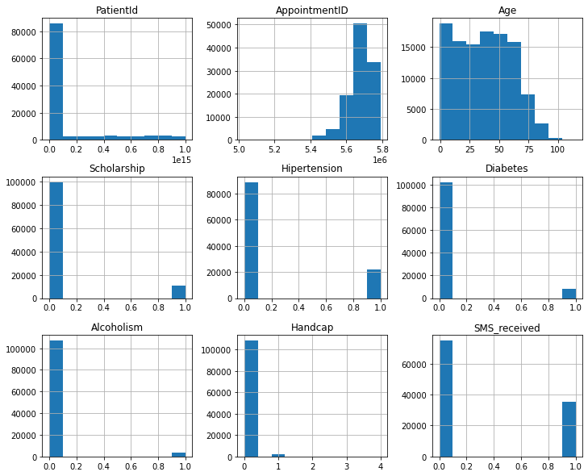

```python
df.hist(figsize=(12,10));
```

### Data Cleaning

> I notice some strange numbers in the data. There is/are patients with -1 as their age. Since that is impossible, I will be taking care of that.

> First, lets get rid of redundant columns by using the .drop() method.

> Then we will inspect why the dataset has a -1 for age and to see if we can set the value to 0 instead by using the .replace() method

> Then we will change 'no-show' to 'no_show' so that the data labels are more consistent by using .rename() method.

```python
df.drop(['PatientId', 'AppointmentID'], axis=1, inplace=True)
```

```python
df.head()
```

|  | Gender | ScheduledDay | AppointmentDay | Age | Neighbourhood | Scholarship | Hipertension | Diabetes | Alcoholism | Handcap | SMS_received | No-show |
| --- | --- | --- | --- | --- | --- | --- | --- | --- | --- | --- | --- | --- |
| 0 | F | 2016-04-29T18:38:08Z | 2016-04-29T00:00:00Z | 62 | JARDIM DA PENHA | 0 | 1 | 0 | 0 | 0 | 0 | No |
| 1 | M | 2016-04-29T16:08:27Z | 2016-04-29T00:00:00Z | 56 | JARDIM DA PENHA | 0 | 0 | 0 | 0 | 0 | 0 | No |
| 2 | F | 2016-04-29T16:19:04Z | 2016-04-29T00:00:00Z | 62 | MATA DA PRAIA | 0 | 0 | 0 | 0 | 0 | 0 | No |
| 3 | F | 2016-04-29T17:29:31Z | 2016-04-29T00:00:00Z | 8 | PONTAL DE CAMBURI | 0 | 0 | 0 | 0 | 0 | 0 | No |
| 4 | F | 2016-04-29T16:07:23Z | 2016-04-29T00:00:00Z | 56 | JARDIM DA PENHA | 0 | 1 | 1 | 0 | 0 | 0 | No |

> Great. Those columns are gone. Looks less overwhelming. Now lets set the -1 ages to 0.

```python
df[df['Age'] == -1]
```

|  | Gender | ScheduledDay | AppointmentDay | Age | Neighbourhood | Scholarship | Hipertension | Diabetes | Alcoholism | Handcap | SMS_received | No-show |
| --- | --- | --- | --- | --- | --- | --- | --- | --- | --- | --- | --- | --- |
| 99832 | F | 2016-06-06T08:58:13Z | 2016-06-06T00:00:00Z | -1 | ROMÃO | 0 | 0 | 0 | 0 | 0 | 0 | No |

> Before I set the age to 0, I wanted to take a look if this patient is in all likelihood a newborn. Glad to see the baby doesnt have any of the listed pre-existing conditions. Also this patient did not receive a text, most likely because babies don't have phones. So I will assume this is in fact a newborn.

```python
df['Age'].replace([-1],[0], inplace=True)
```

```python
df[df['Age'] == -1]
```

|  | Gender | ScheduledDay | AppointmentDay | Age | Neighbourhood | Scholarship | Hipertension | Diabetes | Alcoholism | Handcap | SMS_received | No-show |
| --- | --- | --- | --- | --- | --- | --- | --- | --- | --- | --- | --- | --- |

> Great. That irregularity is gone.

```python
df.rename(columns={'No-show': 'no_show'}, inplace=True)
df.head()
```

|  | Gender | ScheduledDay | AppointmentDay | Age | Neighbourhood | Scholarship | Hipertension | Diabetes | Alcoholism | Handcap | SMS_received | no_show |
| --- | --- | --- | --- | --- | --- | --- | --- | --- | --- | --- | --- | --- |
| 0 | F | 2016-04-29T18:38:08Z | 2016-04-29T00:00:00Z | 62 | JARDIM DA PENHA | 0 | 1 | 0 | 0 | 0 | 0 | No |
| 1 | M | 2016-04-29T16:08:27Z | 2016-04-29T00:00:00Z | 56 | JARDIM DA PENHA | 0 | 0 | 0 | 0 | 0 | 0 | No |
| 2 | F | 2016-04-29T16:19:04Z | 2016-04-29T00:00:00Z | 62 | MATA DA PRAIA | 0 | 0 | 0 | 0 | 0 | 0 | No |
| 3 | F | 2016-04-29T17:29:31Z | 2016-04-29T00:00:00Z | 8 | PONTAL DE CAMBURI | 0 | 0 | 0 | 0 | 0 | 0 | No |
| 4 | F | 2016-04-29T16:07:23Z | 2016-04-29T00:00:00Z | 56 | JARDIM DA PENHA | 0 | 1 | 1 | 0 | 0 | 0 | No |

> Here I changed the column "No-show" to be more consistent. I also felt like the '-' might be a little annoying in the future.

```python
df.head()
```

|  | Gender | ScheduledDay | AppointmentDay | Age | Neighbourhood | Scholarship | Hipertension | Diabetes | Alcoholism | Handcap | SMS_received | no_show |
| --- | --- | --- | --- | --- | --- | --- | --- | --- | --- | --- | --- | --- |
| 0 | F | 2016-04-29T18:38:08Z | 2016-04-29T00:00:00Z | 62 | JARDIM DA PENHA | 0 | 1 | 0 | 0 | 0 | 0 | No |
| 1 | M | 2016-04-29T16:08:27Z | 2016-04-29T00:00:00Z | 56 | JARDIM DA PENHA | 0 | 0 | 0 | 0 | 0 | 0 | No |
| 2 | F | 2016-04-29T16:19:04Z | 2016-04-29T00:00:00Z | 62 | MATA DA PRAIA | 0 | 0 | 0 | 0 | 0 | 0 | No |
| 3 | F | 2016-04-29T17:29:31Z | 2016-04-29T00:00:00Z | 8 | PONTAL DE CAMBURI | 0 | 0 | 0 | 0 | 0 | 0 | No |
| 4 | F | 2016-04-29T16:07:23Z | 2016-04-29T00:00:00Z | 56 | JARDIM DA PENHA | 0 | 1 | 1 | 0 | 0 | 0 | No |

## Exploratory Data Analysis

### Research Question 1: Does receiving a text reminder help with appointment turn out?

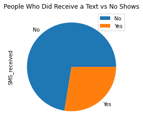

```python
df.groupby("no_show").sum().plot.pie(y="SMS_received",title='People Who Did Receive a Text vs No Shows');
```

> Here we created a pie chart where we can see the proportion of how many people who did receive a text reminder showed up to an appointment.

> Looks like many of those who received a text showed up to their appointment. Around 75% of people showed up after receiving a text.

```python
df["No_SMS"] = df["SMS_received"].map(lambda r: int(not bool(r)))
```

> I reversed the 0's and 1's so that I am able to make a pie chart with those who did not receive a text reminder.

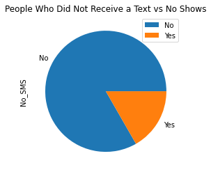

```python
df.groupby("no_show").sum().plot.pie(y="No_SMS",title='People Who Did Not Receive a Text vs No Shows');
```

> Here we created a pie chart where we can see the proportion of how many people who did not receive a text reminder showed up to an appointment.

> Here we see that many of those who did not receive a text reminder still showed up. In fact, more people showed up! Interesting finding.

### Research Question 2 : Can scholarship status help provide hints as to whether a patient shows up or not?

```python
df[df['no_show'] == "Yes"].Scholarship.value_counts()
```

```
0    19741
1     2578
Name: Scholarship, dtype: int64
```

```python
df[df['no_show'] == "No"].Scholarship.value_counts()
```

```
0    79925
1     8283
Name: Scholarship, dtype: int64
```

```python
df.groupby("no_show").sum()
```

| no_show | Age | Scholarship | Hipertension | Diabetes | Alcoholism | Handcap | SMS_received | No_SMS |
| --- | --- | --- | --- | --- | --- | --- | --- | --- |
| No | 3333387 | 8283 | 18029 | 6513 | 2683 | 2006 | 25698 | 62510 |
| Yes | 765936 | 2578 | 3772 | 1430 | 677 | 453 | 9784 | 12535 |

> I am making sure that so far my code make sense and that I am not making any errors in the counting of scholarship vs no shows.

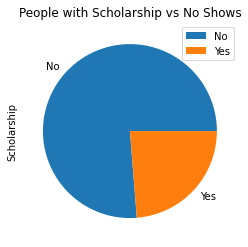

```python
df.groupby("no_show").sum().plot.pie(y="Scholarship", title='People with Scholarship vs No Shows');
```

```python
df["No_Scholarship"] = df["Scholarship"].map(lambda r: int(not bool(r)))
```

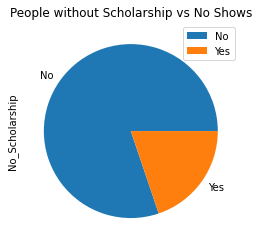

```python
df.groupby("no_show").sum().plot.pie(y="No_Scholarship", title='People without Scholarship vs No Shows');
```

```python
df.groupby("no_show").sum()
```

| no_show | Age | Scholarship | Hipertension | Diabetes | Alcoholism | Handcap | SMS_received | No_SMS | No_Scholarship |
| --- | --- | --- | --- | --- | --- | --- | --- | --- | --- |
| No | 3333387 | 8283 | 18029 | 6513 | 2683 | 2006 | 25698 | 62510 | 79925 |
| Yes | 765936 | 2578 | 3772 | 1430 | 677 | 453 | 9784 | 12535 | 19741 |

> Here we created a pie chart where we can see the proportion of how many people with and without scholarships (respectively) showed up to an appointment.

> We see a simliar story with the previous question. Whether you had a scholarship or not, it seems like the proportions are about the same.

# Question 3: Are older people more likely to show up to an apppointment?

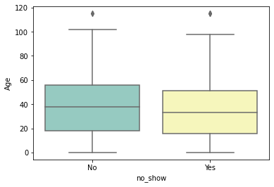

```python
sns.boxplot(x='no_show', y='Age', data=df, palette='Set3');
```

> Here we created a box plot using seaborn that takes the no-shows and ages of patients and plots them so that we can see how old no shows and show ups are.

> This chart shows that those who did show up to their appointment are in fact more older.

## Conclusions

> We can see that receiving an SMS reminder and whether or not a patient was participating in the scholarship program point toward a similar story. In addition, we can see that people who did show up to their appointment are older. A deeper dive into statistical analysis to see if they are statistically significant is necessary.

# Limitations

> There are some limitations of the data. I do think 100k people is a bit low for a sample size of a country of 200 million people. There could be biases in data collection that might cause the data analysis be compromised because of those biases.

> In addition, it does seem strange that both scholarship and SMS received collection points returned similar results. This leads me to believe that there are limitations with the way data was collected and represented as just binary 1/0, yes/no.

# Resources Used

> Had a friend help me with some documentation.

> Used this link to learn how to do pie charts: https://pandas.pydata.org/pandas-docs/stable/reference/api/pandas.Series.plot.pie.html

> Used this link that guided me on using map method: https://pandas.pydata.org/docs/reference/api/pandas.Series.map.html

> Used this link to help with seaborn documentation: https://seaborn.pydata.org/generated/seaborn.boxplot.html

> Also used Udacity lessons as reference to help me clean and wrangle the data.

```python
from subprocess import call
call(['python', '-m', 'nbconvert', 'Investigate_a_Dataset.ipynb'])
```

```
255
```